# Diabetes Prediction

DSCI 310, group 10: Niki Duan, Vivian Pu, Nathan Sihombing, Yun Tian

# Abstract Summary

This study investigates the use of machine learning techniques to predict diabetes status using clinical and demographic data from the Pima Indian Diabetes dataset. The dataset includes physiological variables such as glucose level, body mass index (BMI), age, and number of pregnancies.

# Introduction

## Background Information

Diabetes is a chronic metabolic disease that affects millions of people worldwide, with significant health consequences if not properly managed (Spinelli et al., 2020). Early detection of diabetes is critical for preventing complications such as cardiovascular disease, kidney dysfunction, nerve damage, and vision problems (Spinelli et al., 2020). Women may face unique challenges related to diabetes, including an increased risk of pregnancy-related complications and a higher susceptibility to certain cancers (Berg, 2005).

Accurate prediction of diabetes using clinical and demographic data can help identify individuals at risk, enabling timely interventions and better management of the disease.

In this project, we aim to use statistical and machine learning methods to predict the presence of diabetes in individuals based on relevant clinical measurements and features from the dataset.

## Research Question

The question we will try to answer with this project is: “Can we predict the presence of diabetes in individuals based on clinical and demographic features?”

This question sets up the possibility of conducting statistical analyses and building predictive models to determine which features are most strongly associated with diabetes and to estimate the probability of an individual having the disease.

We have framed our question based on previous studies that have shown certain clinical indicators, such as high blood glucose, BMI, age, and family history, are strongly associated with diabetes risk. For example, the Pima Indian study dataset has been widely used to develop predictive models for diabetes, highlighting the role of these risk factors in disease onset (Chang et al., 2022, Roumie et al., 2020).

## Dataset Used

The unprocessed dataset was acquired from the UCI Machine Learning Repository and is originally from the National Institute of Diabetes and Digestive and Kidney Diseases. The version used in this project was processed by a contributor on OpenML (https://www.openml.org/search?type=data&status=active&id=43483) and contains information on blood pressure, diabetes status, and other health-related variables of females. Based on the diagnostic measurements included in the dataset, the objective is to predict whether a patient has diabetes. The dataset was selected from a larger database using several constraints. Specifically, all patients are female, 21 years of age or older, and of Pima Indian heritage.

The dataset attributes are as follows:

- Pregnancies: Number of pregnancies
- Glucose: Blood glucose level
- BloodPressure: Blood pressure measurement
- SkinThickness: Skinfold thickness
- Insulin: Blood insulin level
- BMI: Body Mass Index
- DiabetesPedigreeFunction: Diabetes pedigree function (a score indicating genetic predisposition)
- Age: Age of the patient
- Outcome: Final result (1 = diabetes, 0 = no diabetes)

# EDA

```r
# loading all the required libraries.
library(tidyverse)
library(dplyr)
library(tidymodels)
library(gridExtra)
library(repr)
library(GGally)
options(repr.matrix.max.rows = 6)
set.seed(1)
```

```r
library(OpenML)
# OpenML dataset ID
dataset_id <- 43483

# Download
oml_data <- getOMLDataSet(data.id = dataset_id)
# Extract as data.frame
df <- oml_data$data

head(df)
```

```
##   Pregnancies Glucose BloodPressure SkinThickness Insulin  BMI
## 0           6     148            72            35   169.5 33.6
## 1           1      85            66            29   102.5 26.6
## 2           8     183            64            32   169.5 23.3
## 3           1      89            66            23    94.0 28.1
## 4           0     137            40            35   168.0 43.1
## 5           5     116            74            27   102.5 25.6
##   DiabetesPedigreeFunction Age Outcome
## 0                    0.627  50       1
## 1                    0.351  31       0
## 2                    0.672  32       1
## 3                    0.167  21       0
## 4                    2.288  33       1
## 5                    0.201  30       0
```

**Table 1: `df` the entire dataset, having 9 variables.**

The df is already very clean with no missing values as shown below.

```r
colSums(is.na(df))
```

```
##              Pregnancies                  Glucose            BloodPressure
##                        0                        0                        0
##            SkinThickness                  Insulin                      BMI
##                        0                        0                        0
## DiabetesPedigreeFunction                      Age                  Outcome
##                        0                        0                        0
```

```r
# Columns to check if they contain 0 (which indicates missing values)
cols <- c("Glucose","BloodPressure","SkinThickness","Insulin","BMI")

# Check which columns have 0
sapply(df[ , cols], function(x) any(x == 0))
```

```
##       Glucose BloodPressure SkinThickness       Insulin           BMI
##         FALSE         FALSE         FALSE         FALSE         FALSE
```

```r
summary(df)
```

```
##   Pregnancies        Glucose       BloodPressure    SkinThickness
##  Min.   : 0.000   Min.   : 44.00   Min.   : 24.00   Min.   : 7.00
##  1st Qu.: 1.000   1st Qu.: 99.75   1st Qu.: 64.00   1st Qu.:25.00
##  Median : 3.000   Median :117.00   Median : 72.00   Median :28.00
##  Mean   : 3.845   Mean   :121.68   Mean   : 72.39   Mean   :29.09
##  3rd Qu.: 6.000   3rd Qu.:140.25   3rd Qu.: 80.00   3rd Qu.:32.00
##  Max.   :17.000   Max.   :199.00   Max.   :122.00   Max.   :99.00
##     Insulin           BMI        DiabetesPedigreeFunction      Age
##  Min.   : 14.0   Min.   :18.20   Min.   :0.0780           Min.   :21.00
##  1st Qu.:102.5   1st Qu.:27.50   1st Qu.:0.2437           1st Qu.:24.00
##  Median :102.5   Median :32.05   Median :0.3725           Median :29.00
##  Mean   :141.8   Mean   :32.43   Mean   :0.4719           Mean   :33.24
##  3rd Qu.:169.5   3rd Qu.:36.60   3rd Qu.:0.6262           3rd Qu.:41.00
##  Max.   :846.0   Max.   :67.10   Max.   :2.4200           Max.   :81.00
##     Outcome
##  Min.   :0.000
##  1st Qu.:0.000
##  Median :0.000
##  Mean   :0.349
##  3rd Qu.:1.000
##  Max.   :1.000
```

**Table 2: Baseline characteristics of participants included in the diabetes dataset, presented as minimum, 1st quartile, median, mean, 3rd quartile, and maximum values for each variable**

Dataset Overview - Total Observations: Not shown directly, but typical for this dataset is 768 rows. - Target Variable: Outcome (binary: 0 = no diabetes, 1 = diabetes). - Mean Outcome: 0.349. About 34.9% of the patients in the dataset have diabetes.

Potential issue to address: Class Imbalance: Only ~35% of cases are diabetic, so model evaluation should consider metrics like precision, recall, or F1-score.

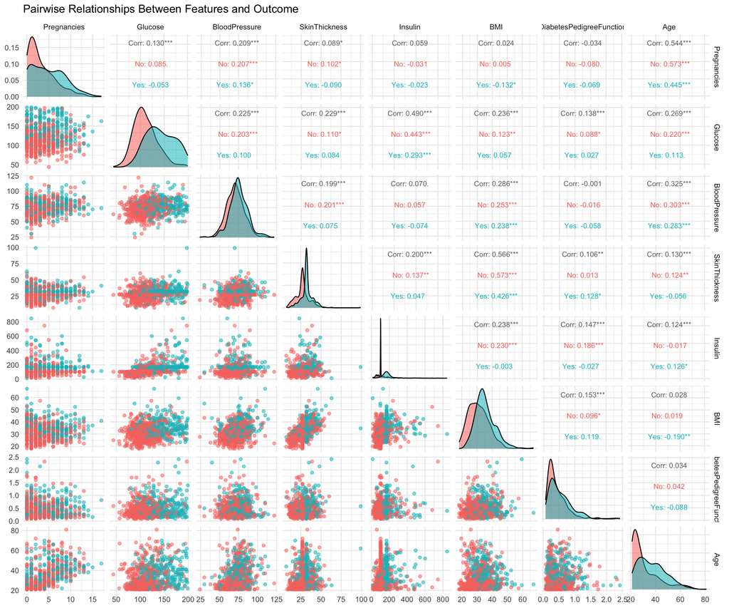

```r
# Ensure Outcome is a factor for coloring
df$Outcome <- factor(df$Outcome, levels=c(0,1), labels=c("No","Yes"))

# Select numeric columns and the target
plot_df <- df %>% select(Pregnancies, Glucose, BloodPressure,
                         SkinThickness, Insulin, BMI,
                         DiabetesPedigreeFunction, Age, Outcome)

# Generate pair plot with coloring by Outcome
ggpairs(plot_df,
        aes(color = Outcome, alpha = 0.5),
        columns = 1:8,   # numeric columns
        upper = list(continuous = wrap("cor", size = 3)), # show correlation in upper panel
        lower = list(continuous = "points"),
        diag = list(continuous = "densityDiag")) +
  theme_minimal() +
  ggtitle("Pairwise Relationships Between Features and Outcome")
```

# Methods & Results

To predict diabetes status, we performed a supervised classification analysis using a random forest model in R (R Core Team, 2019). And the following R packages were used to perform the analysis: knitr (Xie 2014), tidyverse (Wickham 2017), and Quarto (Allaire et al 2022).

First, the dataset was imported into R as a data frame. The outcome variable representing diabetes status was converted to a factor to ensure that the task was treated as a classification problem rather than regression. All predictor variables were retained as features for model training.

The dataset was then partitioned into training and testing subsets using an 80/20 split. Stratified sampling was applied to preserve the class distribution of the diabetes outcome variable in both subsets. This ensured that the model was trained and evaluated on representative data.

A random forest classifier was trained using the training dataset. The model was fit using 500 decision trees, and the number of variables randomly sampled at each split was set to the default value (the square root of the number of predictors). A decision tree is a supervised learning model that makes predictions by recursively splitting the data into subsets based on feature values, forming a tree-like structure of decision rules that lead to a final outcome. Random forest was selected because it is robust to nonlinear relationships, automatically captures interactions between variables, and is less prone to overfitting compared to a single decision tree.

After training, the fitted model was used to generate predictions on the held-out test dataset. These predictions were compared against the true diabetes labels to evaluate model performance.

Model performance was assessed using a confusion matrix. From the confusion matrix, several evaluation metrics were calculated, including:

- Accuracy, representing the proportion of correctly classified observations.
- Precision, measuring the proportion of predicted positive cases that were truly positive.
- Recall (sensitivity), measuring the proportion of actual positive cases correctly identified.
- F1 score, representing the harmonic mean of precision and recall.

The confusion matrix was visualized as a heatmap to provide a graphical summary of classification performance. Additionally, a summary table was created to report the accuracy, precision, recall, and F1 score of the model.

All analyses were conducted in R using the randomForest and caret packages.

```r
# Load required libraries
library(randomForest)
library(caret)
```

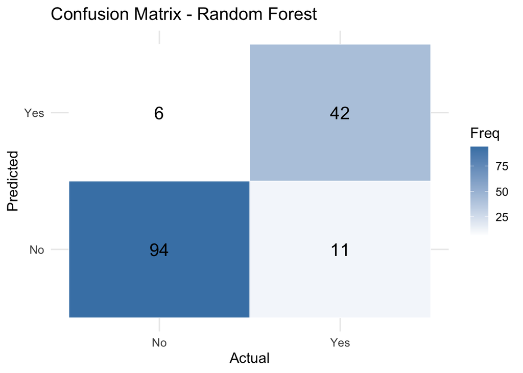

```r
df$Outcome <- as.factor(df$Outcome)

# split training and testing set
train_index <- createDataPartition(df$Outcome, p = 0.8, list = FALSE)
train_data <- df[train_index, ]
test_data  <- df[-train_index, ]

rf_model <- randomForest(
  Outcome ~ .,
  data = train_data,
  ntree = 500,
  importance = TRUE
)

# apply the model on the test set
predictions <- predict(rf_model, newdata = test_data)

cm <- confusionMatrix(predictions, test_data$Outcome)
cm_table <- as.data.frame(cm$table)

colnames(cm_table) <- c("Prediction", "Reference", "Freq")

# plot the confusion matrix
ggplot(cm_table, aes(x = Reference, y = Prediction, fill = Freq)) +
  geom_tile(color = "white") +
  geom_text(aes(label = Freq), size = 6) +
  scale_fill_gradient(low = "white", high = "steelblue") +
  labs(
    title = "Confusion Matrix - Random Forest",
    x = "Actual",
    y = "Predicted"
  ) +
  theme_minimal(base_size = 14)
```

**Figure 2. Confusion matrix for the random forest model predicting diabetes status on the test dataset. The matrix shows the number of true positives, true negatives, false positives, and false negatives, comparing predicted classifications to the actual outcomes.**

```r
# Overall accuracy
accuracy <- cm$overall["Accuracy"]

# For binary classification (Positive class is usually the first level)
precision <- cm$byClass["Precision"]
recall    <- cm$byClass["Recall"]
f1        <- cm$byClass["F1"]

metrics_table <- data.frame(
  Metric = c("Accuracy", "Precision", "Recall", "F1 Score"),
  Value  = c(accuracy, precision, recall, f1)
)

metrics_table
```

```
##              Metric     Value
## Accuracy   Accuracy 0.8888889
## Precision Precision 0.8952381
## Recall       Recall 0.9400000
## F1         F1 Score 0.9170732
```

**Table 3. Performance metrics for the random forest model predicting diabetes on the test dataset, including accuracy, precision, recall, and F1 score.**

# Discussion

These results are somewhat consistent with expectations. Random forest models are known to perform well on structured clinical datasets because they can capture nonlinear relationships and interactions among variables without requiring strong parametric assumptions.

Importantly, the dataset used in this analysis includes only female participants. This is a significant limitation. Biological sex influences insulin sensitivity, fat distribution, hormonal regulation, and cardiovascular risk profiles, all of which contribute to diabetes development. As highlighted by Kautzky-Willer, Leutner, and Harreiter (2023), there are well-documented sex differences in the pathophysiology, risk factors, and clinical presentation of type 2 diabetes. Therefore, a model trained exclusively on female data may not generalize to males or mixed populations. Future work should incorporate sex as a biological variable and evaluate whether predictive performance differs between males and females. Sex-specific models or interaction analyses may improve both accuracy and clinical relevance.

These findings raise several additional future questions. First, how would this model perform on external validation datasets from different populations or healthcare settings? Second, would incorporating additional biomarkers, such as lipid profiles or inflammatory markers, improve predictive power? Third, could more advanced ensemble methods (e.g., gradient boosting) outperform random forests in this context? Finally, beyond prediction, future studies could explore interpretability methods (e.g., feature importance ranking or SHAP values) to better understand which risk factors most strongly drive model decisions.

Overall, this study demonstrates that machine learning approaches can effectively predict diabetes status using clinical data, but broader validation and consideration of sex differences are necessary before clinical implementation.

# References

- “OpenML.” Openml.org, 2025, www.openml.org/search?type=data&id=43483&sort=runs&status=active.
- Chang, V., Bailey, J., Xu, Q. A., & Sun, Z. (2022). Pima Indians diabetes mellitus classification based on machine learning (ML) algorithms. Neural computing & applications, 1–17. Advance online publication. https://doi.org/10.1007/s00521-022-07049-z
- Roumie, C. L., Hung, A. M., Russell, G. B., Basile, J., Kreider, K. E., Nord, J., Ramsey, T. M., Rastogi, A., Sweeney, M. E., Tamariz, L., Kostis, W. J., Williams, J. S., Zias, A., Cushman, W. C., & SPRINT Research Group (2020). Blood Pressure Control and the Association With Diabetes Mellitus Incidence: Results From SPRINT Randomized Trial. Hypertension (Dallas, Tex. : 1979), 75(2), 331–338. https://doi.org/10.1161/HYPERTENSIONAHA.118.12572
- Kautzky-Willer, A., Leutner, M., & Harreiter, J. (2023). Sex differences in type 2 diabetes. Diabetologia, 66(6), 986–1002. https://doi.org/10.1007/s00125-023-05891-x
- Spinelli, R., Parrillo, L., Longo, M. et al. Molecular basis of ageing in chronic metabolic diseases. J Endocrinol Invest 43, 1373–1389 (2020). https://doi.org/10.1007/s40618-020-01255-z
- Berg M. (2005). Pregnancy and diabetes: how women handle the challenges. The Journal of perinatal education, 14(3), 23–32. https://doi.org/10.1624/105812405X57552
- Allaire, J. J., Charles Teague, Carlos Scheidegger, Yihui Xie, and Christophe Dervieux. 2022. “Quarto.” https://doi.org/10.5281/zenodo.5960048.
- R Core Team. 2019. R: A Language and Environment for Statistical Computing. Vienna, Austria: R Foundation for Statistical Computing. https://www.R-project.org/.
- Wickham, Hadley. 2017. Tidyverse: Easily Install and Load the ’Tidyverse’. https://CRAN.R-project.org/package=tidyverse.
- Xie, Yihui. 2014. “Knitr: A Comprehensive Tool for Reproducible Research in R.” In Implementing Reproducible Computational Research, edited by Victoria Stodden, Friedrich Leisch, and Roger D. Peng. Chapman; Hall/CRC. http://www.crcpress.com/product/isbn/9781466561595.